# **Réseau multicouche drug/PPI pour le microbiote cutané**

Elliot Fontaine

2023-06-09

# **0. Initialisation de l’environnement de travail**

Choisir le répertoire de travail. En plus de ce `.Rmd`, il doit contenir le fichier `rest_functions.R`, et les fichiers `prots_skin_infl.txt`, `BIOGRID-ALL-4.4.221.tab3.txt`, `drugbank_uniprot_links_2` dans un répertoire ‘data’.

```r
setwd("/home/elliot/github/multilayer-skin")
```

Les modules nécessaires sont les suivants:

```r
# Général
library(tidyverse)
library(readr)

# Web APIs
library(httr)
library(jsonlite)
library(biogridr)
source("rest_functions.R")

# Manipulation de graphes
library(igraph)
library(SteinerNet)
library(netOmics)
```

# **I. Couche PPI (Protein-Protein Interactions) de l’humain**

## Création d’une liste de protéines cibles pour le réseau PPI

Le fichier `prots_skin_infl.txt` contient une liste de protéines reconnues comme ayant un rôle dans l’inflammation de la peau. On va chercher à obtenir leur environnement métabolique proche: on liste les pathways KEGG dans lesquels elles se trouvent, puis on récupère la liste des protéines impliquées dans ces pathways.

```r
# Lecture du contenu du fichier des protéines impliquées dans l'inflammation de la peau
uniprot_ids <- read.table(
  "data/prots_skin_infl.txt",
  header = TRUE,
  sep = "\t",
  stringsAsFactors = FALSE,
  encoding = "UTF-8"
)
uniprot_ids <- as.vector(uniprot_ids$UniProtKB)
# Récupérer les pathways KEGG pour les IDs UniProt
kegg_ids <- getKeggIdFromUniprot(uniprot_ids)
kegg_ids <- as.vector(kegg_ids$To)
pathway_ids <- unique(getKeggPathways(kegg_ids))
# Récupérer tous les gènes associes au pathways
genes_ids <- unique(getGenesFromPathways(pathway_ids))
# Retour aux IDs UniProt pour les gènes
enz_ids <- getUniprotIdFromKegg(genes_ids)
enz_ids <- subset(enz_ids, Reviewed == "reviewed")
```

## Extraction de l’interactome protéine-protéine humain de BioGRID

Le fichier `BIOGRID-ALL-4.4.221.tab3.txt` peut être téléchargé [ici](https://downloads.thebiogrid.org/BioGRID). On exclue les entrées où il manque un ID UniProt (ceux ayant ‘-’ comme valeur), pour éviter de se retrouver avec un vertex ‘-’ ne correspondant pas à une protéine.

```r
biogrid <- read_tsv("data/BIOGRID-ALL-4.4.221.tab3.txt") %>%
  dplyr::select(
    "SWISS-PROT Accessions Interactor A",
    "SWISS-PROT Accessions Interactor B",
    "Organism Name Interactor A"
  ) %>%
  set_names("A", "B", "Species") %>%
  filter(Species == "Homo sapiens") %>%
  dplyr::select(-Species) %>%
  filter(A != "-") %>%
  filter(B != "-")

# Création du graphe
graph_human <- igraph::graph_from_data_frame(biogrid, directed = FALSE)

# Ajout d'attributs / tags
V(graph_human)$type <- "protein"
V(graph_human)$species <- "Homo sapiens"
E(graph_human)$type <- "PPI"
```

```r
summary(graph_human)
```

```
## IGRAPH 51b3b24 UN-B 23355 1068084 --
## + attr: name (v/c), type (v/c), species (v/c), type (e/c)
```

## Recherche du sous-arbre de Steiner contenant les protéines cibles

Voir https://github.com/krashkov/SteinerNet/blob/master/vignettes/tutorial.pdf pour le tutoriel de SteinerNet. Nos “terminals” dans le sens du problème de l’arbre de Steiner sont les nœuds correspondants aux protéines de l’environnement métabolique proche. Comme on utilise une heuristique (SP = Shortest Path based approximation), le sous-réseau obtenu sera différent (en nombre de vertices et edges) à chaque fois qu’on exécute le code suivant, à moins d’utiliser une graine aléatoire fixée.

```r
# On s'assure que la liste de "terminals" ne contient pas des nœuds non-présents dans le réseau humain
enz_ids <- enz_ids %>% filter(
  Entry %in% biogrid$A | Entry %in% biogrid$B
)
# Recherche du sous-réseau
PPI_layer <- steinertree(type = "SP", terminals = enz_ids$Entry, graph = graph_human, color = FALSE, merge = FALSE)[[1]]

# Alléger l'environnement
remove(biogrid, enz_ids, graph_human)
```

```r
summary(PPI_layer)
```

```
## IGRAPH f9a9fb5 UN-B 1752 1751 --
## + attr: name (v/c), type (v/c), species (v/c), color (v/c), type (e/c)
```

On obtient donc la couche principale de notre réseau, constituée des interactions protéines-protéines. Les nœuds “terminals” (recherchés) sont colorés en rouge et les autres en jaune. Il est possible de la visualiser de manière dynamique avec `tkplot(PPI_layer)`, ou bien avec `plot` :

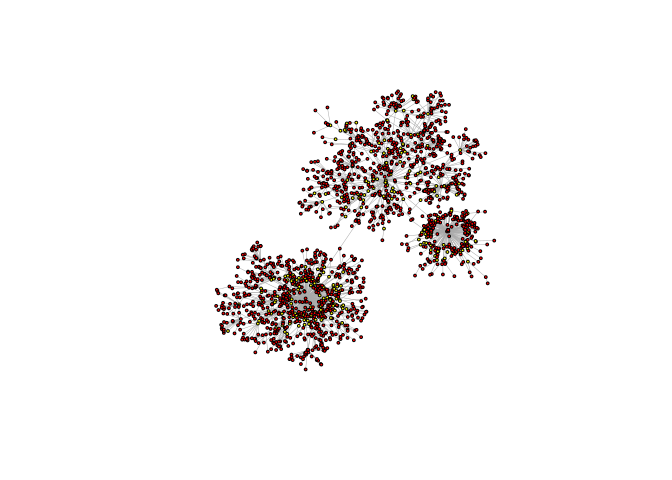

```r
plot(
  PPI_layer,
  vertex.label = NA,
  edge.width = 0.5,
  vertex.size = 2,
  layout = layout_with_fr
)
```

Regardons les 5 nœuds ayant le plus de connexions:

```r
PPI_degree <- tibble(
  V(PPI_layer)$name,
  degree(PPI_layer,
    mode = "total"
  )
) %>%
  set_names("Protein", "Degree") %>%
  arrange(desc(Degree))

print(PPI_degree[1:5, ])
```

```
## # A tibble: 5 × 2
##   Protein Degree
##   <chr>    <dbl>
## 1 Q09472     316
## 2 P04637     196
## 3 P23769      74
## 4 P49327      62
## 5 P50402      43
```

# **II. Couche des médicaments (drugs)**

## Création du graphe isolé des médicaments

La couche des médicaments est particulière car elle est sans arêtes (c’est un graphe isolé). En effet, on ne s’intéresse qu’aux interactions drug-protein, pas à de possibles interactions drug-drug. On crée un graphe, et pas une simple liste, car la fonction `combine_layers` prend 2 graphes en entrée.

```r
# Lecture du fichier CSV
drugbank <- read_csv("data/drugbank_uniprot_links_2.csv") %>%
  filter(`UniProt ID` %in% V(PPI_layer)$name)

# Infos sur les arêtes drug-protein
drugbank_relations <- data.frame(
  from = drugbank$`DrugBank ID`,
  to = drugbank$`UniProt ID`,
  type = "DPI" # == drug-protein interaction
)

# Création du graphe sans arêtes des médicaments
drugs <- unique(drugbank$`DrugBank ID`)
graph_drugbank <- make_empty_graph(directed = FALSE) %>%
  add_vertices(length(drugs), name = drugs, type = "drug", color = "pink"
)
remove(drugs)
```

## Création du “multiplex” avec `combine_layers`

On utilise le package `netOmics` d’ADLab pour combiner la couche des médicaments à celle des protéines. C’est un multiplex entre parenthèses car on se retrouve avec un seul graphe, où la couche des nœuds est déterminée par un attribut de nœud (**type**).

```r
drug_PPI_layers <- combine_layers(
  graph1 = PPI_layer,
  graph2 = graph_drugbank,
  interaction.df = drugbank_relations
)
# Alléger l'environnement
remove(drugbank, drugbank_relations, graph_drugbank)
```

```r
summary(drug_PPI_layers)
```

```
## IGRAPH a12630c UN-B 4664 8989 --
## + attr: species (v/c), type (v/c), color (v/c), name (v/c), type (e/c)
```

Visualisons le graphe nouvellement créé:

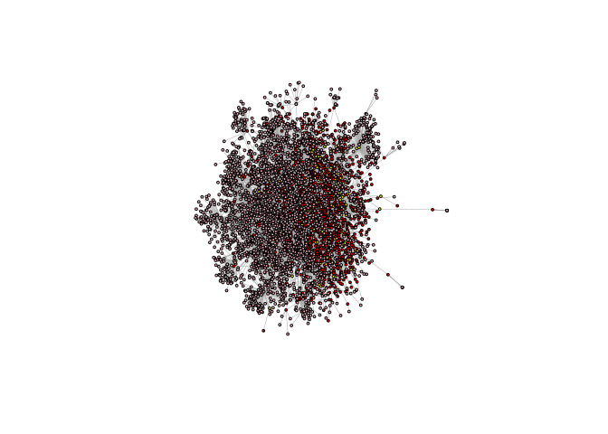

```r
plot(
  drug_PPI_layers,
  vertex.label = NA,
  edge.width = 0.5,
  vertex.size = 2,
  layout = layout_with_fr
)
```

# **Couche PPI du microbiote**

## Création des pangénomes bactériens

Voir `pangenomes.Rmd`